# Lista 3

2022-07-01

# Droga 6MP x Placebo

Considerando os dados do tempo em semanas até a remissão da leucemia, os pacientes foram divididos em dois grupos, onde um grupo recebeu o medicamento 6MP e o outro grupo uma substˆancia in´oqua (placebo). Para esses dois grupos temos a seguinte, curva de sobrevivência estimada:

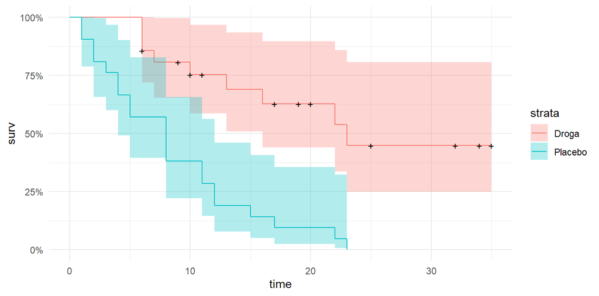

Curva de sobrevicência para ambos os grupos

## Verificação da Linearização

Com as figuras que serão apresentadas nessa subseção verificaremos qual o modelo paramétrico mais adequado ao conjunto de dados do tempo de remissão da leucemia. Verificaremos qual gráfico possui os pontos que se traçassemos uma reta mais se assemelharia com a bissetriz (y = x). Isto pois estamos verificando se a linearização do modelo paramétrico, condiz com uma linearização da sobrevivência estimada por Kaplan-Meier, assim o modelo com a linearização da sobrevivência estimada mais adequada, resultará em um melhor ajuste do modelo paramétrico.

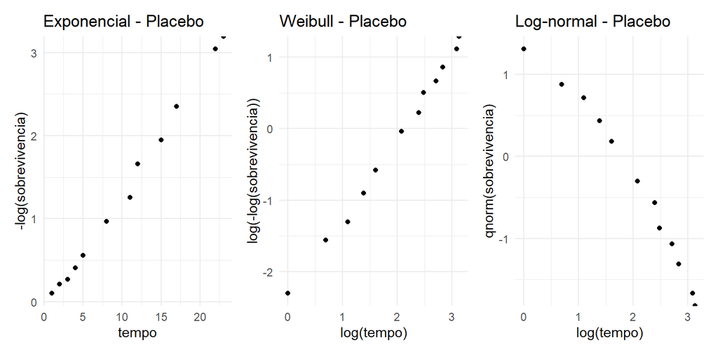

Linearização do modelos paramétricos para o Placebo

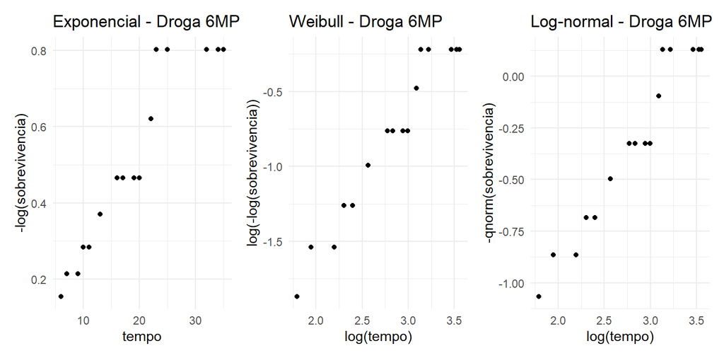

Linearização do modelos paramétricos para o Droga 6MP

### Teste de Hipóteses

Usaremos o teste de razão de verossimilhanças em modelos encaixados e utilizaremos a Gama Generalizada como o modelo mais geral.

$$H_0:\text{O modelo testado é mais
adequado que o modelo Generalizado.}$$
$$H_1:\text{O modelo testado não é mais adequado
que o modelo Generalizado.}$$

Assim buscamos os modelos que não rejeitem a hipóteste $H_0$, assim para os modelos Exponencial, Weibull e Log-normal, temos os seguintes p-valores: 0, 0 e 0, respectivamente, assim em todos temos evidências para a rejeição de $H_0$, logo nenhum é mais adequado que a Gama Generalizada.

Utilizando o modelo Weibull como modelo generalizado e como modelo testado a Exponencial, temos que o p-valor é 0.395, assim não rejeitamos a $H_0$ e reafirmamos o que foi analisado graficamente, que o modelo Exponencial é mais adequado que o modelo Weibull.

## Escolha do modelo adequado

Nessa subseção teremos que escolher o modelo mais adequado somente para o grupo da Droga 6MP, começaremos realizando o teste de hipóteses utilizado anteriormente, no entanto agora só com os dados do grupo com a utilização do remédio.

Considerando apenas os grupo da Droga 6MP, utilizando os modelos Exponencial, Weibull e Log-normal, temos os seguintes p-valores: 0.274, 0.212 e 1, respectivamente, assim em todos não temos evidências para a rejeição de $H_0$, logo todos são mais adequados que a Gama Generalizada.

Utilizando o modelo Weibull como modelo generalizado e como modelo testado a Exponencial, temos que o p-valor é 0.31, assim também não rejeitamos a $H_0$ e temos que o modelo Exponencial é mais adequado que o modelo Weibull.

Assim, escolheremos o modelo exponencial, por não ter evidência contra sua adequação de acordo com o teste de hipóteses, também foi escolhido como o melhor graficamente e por ser o modelo mais simples.